## League of Legends World Championship

The League of Legends World Championships brings 16 teams from various regions to compete for the “Summoner’s Cup”. In a format similar to that of traditional sports, teams are seeded and drawn into groups. The 2018 finals were watched by nearly 100 million people, a staggering number that reflects the popularity and impact of LoL. Given its worldwide influence, LA2024, the group that oversees Los Angeles’ bid for the summer 2024 Olympic Games, would highly consider including eSports and LoL’s virtual reality and entertainment in the games.

I chose the 2018 championships because that was the year my favorite team, SK Telecom of South Korea, failed to make the tournament. As three-time winners of the entire competition (2014, 2016, 2017), I was shocked and disappointed. However, I wanted to understand the new environment. I wanted to take a deeper look at the statistics that mattered in 2018. 2018 marks a turning point — I aimed to determine a way to predict the results of games with high accuracy.

## Looking at the Stats

League of Legends teams, players, and analysts have moved from an emphasis on stylish 1v1 outplays to strategic objective control. Although these outplays do impact the outcome of a game, strong game management and objective control are the true deciders of victory. Objectives like dragons and barons are often cited as deciders of wins and losses. This makes sense: these late-game objectives provide a major damage boost. As such, the winner (IG), a semifinalist, and a quarterfinalist made the top 5 in average dragons per game.

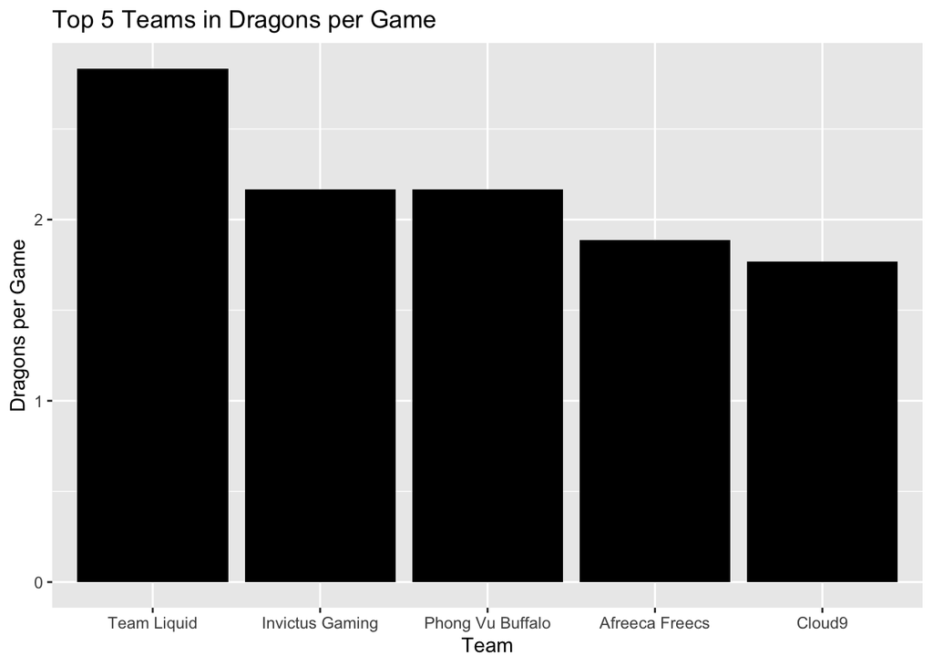

Notably, Team Liquid and Phong Vu Buffalo, did not place well but still captured a high number of dragons. As such, we note that there may be different factors that are more important to game wins. Although dragons and objectives are important in helping teams gain these boosts, teamfights determine the game. Gold is critical in purchasing items to win those fights.

Gold matters more earlier in the game — during that time, a larger gold difference can create a lead that snowballs into victories. A greater difference in gold allows one team to dominate the other in teamfights. Gold difference also helps normalize the data, as some games may result in more actions and thus result in more overall gold. As such, we note that the winner (IG), 2nd place (Fnatic), and two quarterfinalists maintained the highest gold difference at 10 minutes. Room for error still remains: Team Liquid placed only slightly better than the median.

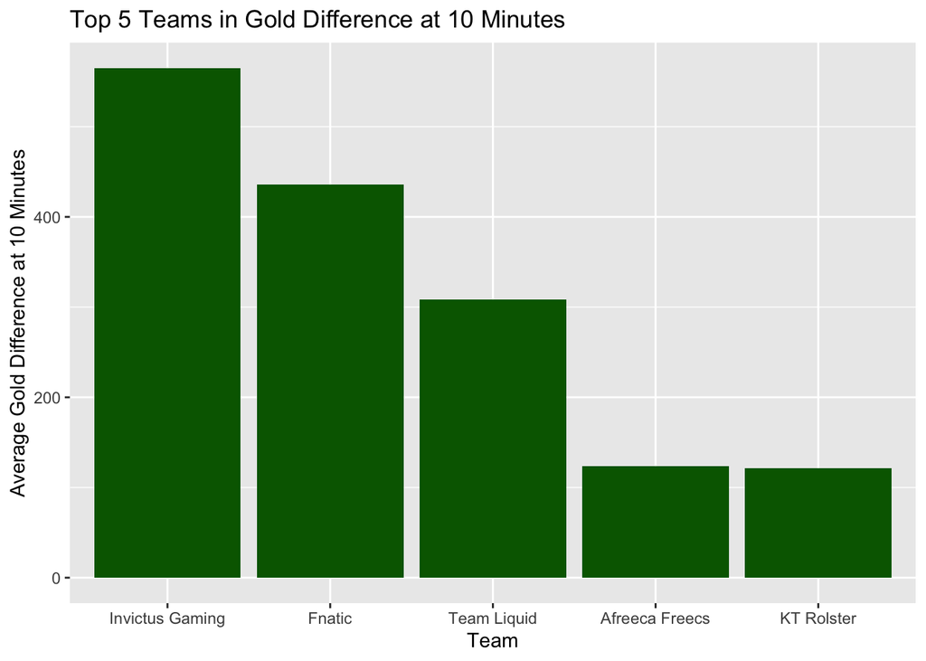

The correlation of success with positive gold difference continues with the teams that did poorly. 4 of the 5 teams depicted performed below average. The only outlier, Edward Gaming, placed as a quarterfinalist.

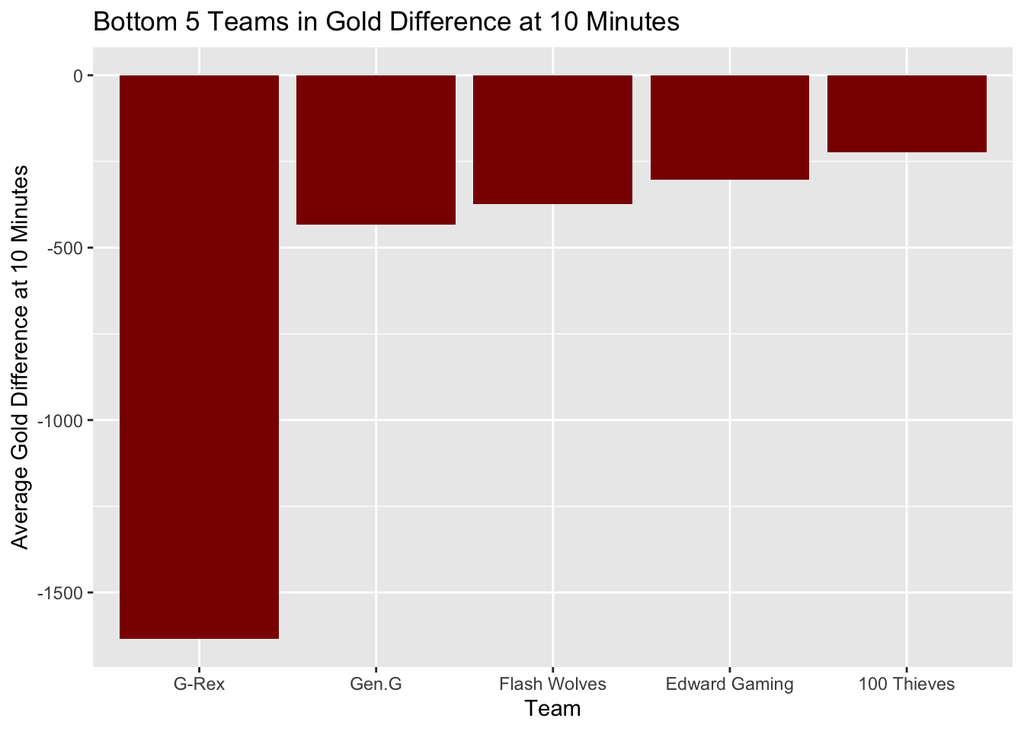

Although these trends are not absolute and can only suggest a correlation, we can tell that gold is critical to these teams. As such, we dive deeper into the importance of gold.

## The Importance of Gold

High gold generation is often the key to victory. During the games, announcers often show graphs of gold for the two teams. As previously mentioned, teams that generated the most gold ended up placing the highest. Gold is essential to purchasing items - understandably, there’s a strong positive correlation between gold earned and gold spent.

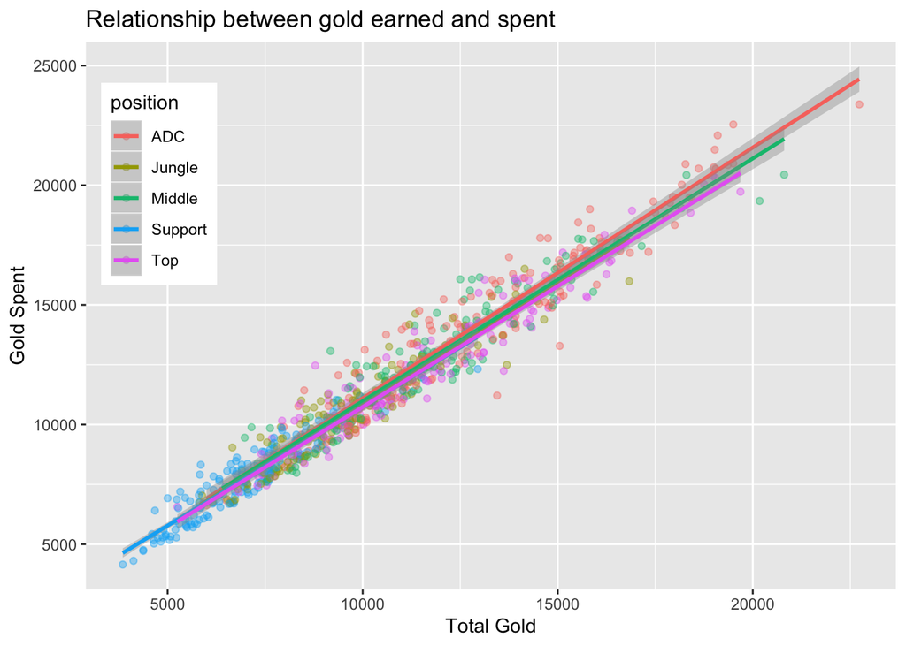

Although we have seen that teams that generated the most gold placed well in the tournament, we have not put this conclusion to the test. As both the result of the games and damage output of each champion are extremely important, we want to see how gold impacts damage per minute of a game.

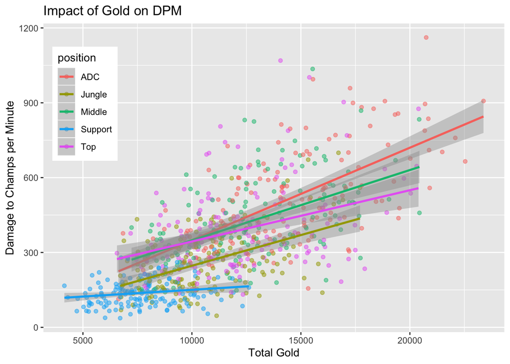

Given this high correlation, we can use a model to see which objectives affect gold generation the most, and thus can advise teams on which goals to focus on. We then can finally confirm that greater gold differential and total gold generated are correlated with greater chances of victory. Notably, we confirm that gold difference creates a stronger relationship.

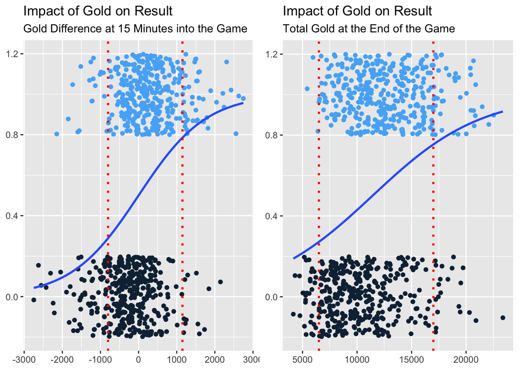

## Impacting gold generation

In the following graphs, we emphasize this important fact: the position of the player is critical to the amount of gold generated. As such, we highly recommend first coloring by position.